# Working with R

Taylor G. White

March 7, 2019

## Tutorials

This tutorial includes both an aggregation of already available learning materials for the R language as well as real-world examples of R in use, aimed at business analysts.

### Get Started

*Download R and RStudio*

- [R](https://cloud.r-project.org/)
- [RStudio](https://www.rstudio.com/products/rstudio/download/)

*Syntax, objects, functions*

What are the basic rules of the language? How are objects created? How do functions work? What controls the flow of operations that are completed?

- [Good overall introduction](http://r-statistics.co/R-Tutorial.html)
- [Data types](https://www.statmethods.net/input/datatypes.html)
- [Scripting style guide](http://adv-r.had.co.nz/Style.html)

### Exploratory Data Analysis (EDA)

Import data, take a look at it, compute basic summary statistics, filter/reshape your data, plot your data.

- [Data import](https://www.datacamp.com/community/tutorials/r-data-import-tutorial)
- [Basic summary statistics](https://www.statmethods.net/stats/descriptives.html)
- [Filter/subset, data reshape, groupwise operations](https://cran.r-project.org/web/packages/dplyr/vignettes/dplyr.html)
- [More dplyr examples](https://dplyr.tidyverse.org/)
- [Plotting with ggplot2](http://r-statistics.co/Complete-Ggplot2-Tutorial-Part1-With-R-Code.html)

### Advanced manipulations

Combine data from multiple sources for analysis. Clean your data for analysis, reshape it for different operations.

- [Combine data with joins](https://stat545.com/bit001_dplyr-cheatsheet.html)
- [Tidying and reshaping data](http://garrettgman.github.io/tidying/)

### Open Data Sources

R has many packages for downloading data available publicly via API.

The St. Louis Federal Reserve (FRED) has publicly available data on economic and social matters, primarily in the United States but also globally. This data can be downloaded across many time frames (depending on how far back the time series go) and on various geographic levels (national, state, county, MSA).

The World Bank has extensive economic, political, and social data on most of the countries in the world, though not all countries have robust statistical services. R’s `WDI` package enables one to programmatically download statistics like economic growth, population, exchange rates, energy consumption, etc. This data is reported annually.

The U.S. census occurs every 10 years and includes economic and social data about life in the U.S. In between each census, there is the American Community Survey (ACS), which captures data on a subset of the U.S. population and makes these estimates available for stakeholders (in 1, 3, and 5 year spans). This data can cover areas as large as the entire U.S. or as small as a city-block (census block).

Financial data can be downloaded from the `quantmod` package via open sources like FRED, Yahoo Finance, and if you have an account, Quandl.

- [FRED](https://cran.r-project.org/web/packages/fredr/vignettes/fredr.html)
- [World Bank](https://cengel.github.io/gearup2016/worldbank.html)
- [US Census](https://cran.r-project.org/web/packages/tidycensus/tidycensus.pdf)
- [Quantmod financial data](https://www.quantmod.com/examples/intro/)

### Interactive Reports

R has features to produce reports programmatically. The great thing about this is that, with a click of a button, you can regenerate a report that will be based on whatever new data or inputs you choose, without having to spend time formatting Excel documents. This introduction was produced using RMarkdown, which is a way of combining (“knitting”) text with R code. Documents can be made that show the underlying code or they can only show fully polished output for reports.

Since RMarkdown allows one to create HTML files (which are read using web browsers), one can generate interactive plots for users to see without knowing any javascript or HTML.

Last, R has a feature to create web applications using only R with a package called `shiny`. These allow users to expose their analytical work to the world for fully interactive use.

- [RMarkdown](https://rmarkdown.rstudio.com/articles_intro.html)
- [HTML/Javascript widgets](http://www.htmlwidgets.org/showcase_leaflet.html)
- [Shiny Web Applications](https://shiny.rstudio.com/gallery/)

### Working with Excel in R

Excel isn’t going away anytime soon, but that doesn’t mean you can’t get away from Excel to do tasks that would otherwise be hard to do without a scripting language. I consider Excel a good tool for sharing information with colleagues and presenting data – it shouldn’t be used for complex calculations, data manipulation, or plotting if it can be avoided.

A common workflow that combines R and Excel is the following:

1. There is some existing business data in Excel
2. Get data from Excel and import it to R
3. Do data manipulation, calculations, plotting in R
4. Export results back to Excel for your colleagues to use

There are many R packages that can help with this work, but you should be careful about which ones you choose because they have additional dependencies (code they rely on to work).

`openxlsx` is my all-around favorite for working with excel in R. It allows one to import data from Excel and Export data and images back to Excel, using only [RTools](https://cran.r-project.org/bin/windows/Rtools/) as a dependency. If all you need to do is read Excel data in R, you should use something simple like the `readxl` package.

There are other R packages that interface with Excel, but these can cause additional headaches. Packages like `xlsx` and `XLConnect` rely on Java to connect to R packages. Most machines have Java installed, but there are often issues with getting the R environment to find the proper java.exe file to use. You’re better off to just avoid this pain if you can.

### Statistical models

These methods are for fitting a given model to a set of data. These models are good for explaining relationships between quantities of interest and can be used for prediction. Each model is built for a particular purpose and they will not perform well if the assumptions underlying the model are violated.

- [Linear regression](https://www.statmethods.net/stats/regression.html) - Fit a linear model via ordinary least squares.
- [Logistic models](https://stats.idre.ucla.edu/r/dae/logit-regression/) - Discrete events (e.g. something happened or didn’t happen)
- [Poisson models](https://stats.idre.ucla.edu/r/dae/poisson-regression/) - Counting processes
- [Time series models](https://www.datascience.com/blog/introduction-to-forecasting-with-arima-in-r-learn-data-science-tutorials) - Follow a single entity over time. Observations are correlated over time.
- [panel data analysis](https://www.princeton.edu/~otorres/Panel101R.pdf) - for data sets that follow entities (e.g. people, companies, countries) over time.
- [quantile regression](https://data.library.virginia.edu/getting-started-with-quantile-regression/) - OLS regression will find the conditional mean – this method can find the conditional Nth percentile, e.g. 10% percentile, median, or 90th percentile.
- [Advanced parametric models](https://stats.idre.ucla.edu/other/dae/)

### Machine learning

These methods can help explain unseen relationships in data that parametric models might not capture. These methods are better for prediction than explanation, and often outperform parametric models in terms of prediction. The downside is you might not be able to explain your results to stakeholders, as many machine learning methods are black boxes.

- [Cluster analysis](https://www.statmethods.net/advstats/cluster.html) - create clusters of entities based on a host of variables
- [Regression and classification trees](https://www.statmethods.net/advstats/cart.html) - Split data into homogeneous groups and continue doing so until a split no longer produces meaningful differences.
- [Neural networks](https://beckmw.wordpress.com/tag/neuralnet/)
- [Random forests](https://www.r-bloggers.com/how-to-implement-random-forests-in-r/) - In parallel, fit many regression trees on bootstrapped input datasets, using a subset of variables each time. Combine the results.
- [Boosted trees](https://xgboost.readthedocs.io/en/latest/R-package/xgboostPresentation.html) - In sequence, fit many small regression trees (not “full” trees with many splits) on bootstrapped input datasets. Combine the results.

## Learning R

R is said to have a steep learning curve, but one is well-rewarded once you get over some of its idiosyncracies. The best advice I have to learn R (and any other language) is to take a little time every day to practice, even if its just for 30 minutes in the morning. Second, use R to solve actual problems that you have. Many introductions out there show you how to do things you don’t ever need to do. This doesn’t help one commit techniques to memory. Instead, work on a real-life problem you have and use Google as your ally. Search “how to do [x] in R” and you’ll be presented with many articles from people that have worked on the same problems.

Aside from Google, your best ally to deal with problems you encounter is [StackOverflow](https://stackoverflow.com/), which is a programming help site. For statistical questions, go to [Cross Validated](https://stats.stackexchange.com/), which often has examples in R.

Below are some additional gotchas and helpful information you should be aware of.

### Something unexpected is happening!

- You ran a function and it is giving you strange output. Make sure that the `class()` of the object(s) you are operating on are what you expected and that it has the data you expect data.
- Inspect your data. Print it to the console, look at the top and bottom of it. Use plots to visualize your whole dataset in various ways. Make sure you aren’t making incorrect assumptions about your data.
- You changed your code in some way, and you are referring to something other than what you expected. Good and consistent naming conventions can help with these problems.

```r
# original code
oldthing = 1

some_important_value = oldthing^2

# updated code
oldThing = 2

some_important_value = oldthing^2 # still returns 1 if you didn't clear your environment!
```

### This code worked the first time but it isn’t working now

You are likely modifying an object in place. This is usually bad and leads to strange errors. The value of the object `thing` is dependent on how many times you ran the `thing = thing + 2` line. This error is unlikely in this case, but it can happen with longer data prep code chunks.

```r
# This is modifying the object in place
thing = 1

thing = thing + 2
```

### I don’t understand that error!

Stackoverflow and Google are your friends. Copy the whole error and paste it into google. See what comes up. If nothing comes up, copy just the first part that isn’t particular to your piece of code and see if a search engine finds something. Chances are, you have made a mistake someone else has made many times before.

### Nothing is working and I’m freaking out!

Relax. Take a break. Walk away from the code for a bit and come back to it when you have regained composure. Chances are, frantically changing bits of code will lead to even more problems. The way to uncover bugs is to isolate the changes you make in order to systematically test each chunk for issues. Frantic changes will mean you could fix one problem and introduce many others, leading you to believe the whole piece of code is broken in some fundamental way.

### I have a lot to do and don’t know how to proceed!

Think before you write any code. Go to a piece of paper or whiteboard and map out the problem you are working on. When you have a decent grasp, write code in a piecewise fashion, instead of trying to tackle everything at once. Small, manageable code pieces that work can be wrapped in functions and pieced together. If there is an error, it’s easy to trace that error to a particular function, instead of having to debug a large piece of [spaghetti](https://en.wikipedia.org/wiki/Spaghetti_code) code.

### Be careful with `factor` vectors

Factors are essentially vectors that have some sort of label, saved as an integer, treated as a discrete value. Some processes will coerce factors back to integer values, which then would allow for numeric operations. Make sure weirdness isn’t happening because of factors.

## Example 1 - Download stock prices, estimate beta

This example demonstrates how to get publicly available data to estimate betas for a set of stock tickers.

*Steps*

- Get prices for multiple stocks: Chevron, ExxonMobile, First Solar Inc., GE, Tesla
- Get values of the S&P 500
- Get values of the risk free interest rate
- Compute monthly returns for all of these series
- Combine data into a single dataset for analysis
- Subtract the risk free rate from asset and market returns
- Regress stock returns in excess of the risk free rate from market returns in excess of the risk free rate
- Extract betas from each model

```r
# Set up your script

# load libraries
library(quantmod) # download data and other financial functions
library(tidyverse) # host of data handling and visualization functions
library(lubridate) # easier handling of dates
```

```r
library(scales) # nice scales for ggplot2
# assign vectors of symbols to objects to be passed to quantmod's getSymbols() function
stock_tickers_vec = c('CVX', 'XOM', 'FSLR', 'GE', 'TSLA')
```

My intention is to run the same data preparation code for all of the symbols, so it wouldn’t matter if I had to do this process for 1 or 10,000 stock tickers. That being said, I always write out my code for the single case to test each piece before wrapping it into a function.

```r
# download daily data for the S&P500, from 2010 to the current date using Yahoo finance data
downloaded_data = getSymbols('^GSPC', auto.assign = F, src = 'yahoo', from = as.Date('2010-01-01'))
```

[output not shown]

[output not shown]

```r
# take a look at the data
class(downloaded_data) # what type of object was downloaded?
```

```
## [1] "xts" "zoo"
```

```r
head(downloaded_data)
```

```
##            GSPC.Open GSPC.High GSPC.Low GSPC.Close GSPC.Volume
## 2010-01-04   1116.56   1133.87  1116.56    1132.99  3991400000
## 2010-01-05   1132.66   1136.63  1129.66    1136.52  2491020000
## 2010-01-06   1135.71   1139.19  1133.95    1137.14  4972660000
## 2010-01-07   1136.27   1142.46  1131.32    1141.69  5270680000
## 2010-01-08   1140.52   1145.39  1136.22    1144.98  4389590000
## 2010-01-11   1145.96   1149.74  1142.02    1146.98  4255780000
##            GSPC.Adjusted
## 2010-01-04       1132.99
## 2010-01-05       1136.52
## 2010-01-06       1137.14
## 2010-01-07       1141.69
## 2010-01-08       1144.98
## 2010-01-11       1146.98
```

```r
tail(downloaded_data)
```

```
##            GSPC.Open GSPC.High GSPC.Low GSPC.Close GSPC.Volume
## 2019-02-28   2788.11   2793.73  2782.51    2784.49  4396930000
## 2019-03-01   2798.22   2808.02  2787.38    2803.69  3972280000
## 2019-03-04   2814.37   2816.88  2767.66    2792.81  3919810000
## 2019-03-05   2794.41   2796.44  2782.97    2789.65  3585690000
## 2019-03-06   2790.27   2790.27  2768.69    2771.45  3786600000
## 2019-03-07   2766.53   2767.25  2739.09    2748.93  3904860000
##            GSPC.Adjusted
## 2019-02-28       2784.49
## 2019-03-01       2803.69
## 2019-03-04       2792.81
## 2019-03-05       2789.65
## 2019-03-06       2771.45
## 2019-03-07       2748.93
```

```r
# get the class of all the columns. This will loop over each column and apply the class function to that column
sapply(downloaded_data, class)
```

```
##      GSPC.Open GSPC.High GSPC.Low GSPC.Close GSPC.Volume GSPC.Adjusted
## [1,] "xts"     "xts"     "xts"    "xts"      "xts"       "xts"
## [2,] "zoo"     "zoo"     "zoo"    "zoo"      "zoo"       "zoo"
```

```r
# Calculate monthly returns. Make sure you know what the underlying values are. In some cases, it's stock prices, in some cases it's the value of an index.
monthly_returns = monthlyReturn(downloaded_data)
head(monthly_returns)
```

```
##            monthly.returns
## 2010-01-29     -0.03823356
## 2010-02-26      0.02851369
## 2010-03-31      0.05879643
## 2010-04-30      0.01475923
## 2010-05-28     -0.08197584
## 2010-06-30     -0.05388244
```

```r
# convert the monthly return to a data.frame and add a date column using the index of the zoo/xts object
returns_df = data.frame(
  monthly_returns
) %>%
  rename(
    return = monthly.returns # make a prettier name for the monthly.returns column
  ) %>%
  mutate(
    # this will shift each date to the start of the month for simplicity of comparison
    date = floor_date(index(monthly_returns), 'month')
  )

head(returns_df) # everything looks good.
```

```
## # A tibble: 6 x 2
##    return date
##     <dbl> <date>
## 1 -0.0382 2010-01-01
## 2  0.0285 2010-02-01
## 3  0.0588 2010-03-01
## 4  0.0148 2010-04-01
## 5 -0.0820 2010-05-01
## 6 -0.0539 2010-06-01
```

Now I want to “wrap” this code into a function, so I can run the same code efficiently without having to repeat my code many times, which will cause errors and headaches.

```r
# create the name for your function. Use a verb to describe it
# The only thing I need to do to get data for other tickers is to change the ticker that is fed through
# This is captured in the first  parameter defined in the get_monthly_returns_function
# The second parameter is from_date, which will determine how far back the data goes
# This parameter has a default value, set to January 1, 2010
# The third parameter is passed to getSymbols and indicates the source of the data. The default is set to yahoo

get_monthly_returns = function(ticker, from_date = as.Date('2010-01-01'), source = 'yahoo') {


  # FIRST CHANGE - sp500 is changed to ticker here, so other tickers can be fed through
  # I also changed the hard-coded from date to from_date, which allows for control of the
  # downloaded dates
  downloaded_data = getSymbols(ticker, auto.assign = F, src = source, from = from_date)

  # SECOND CHANGE -  no need to take a look at the data within the function anymore

  # calculate monthly returns
  monthly_returns = monthlyReturn(downloaded_data)

  # convert the monthly return to a data.frame and add a date column using the index of the zoo/xts object
  returns_df = data.frame(
    monthly_returns
  ) %>%
    rename(
      return = monthly.returns # make a prettier name for the monthly.returns column
    ) %>%
    mutate(
      # this will shift each date to the start of the month for simplicity of comparison
      date = floor_date(index(monthly_returns), 'month'),

      # !!!!!
      # THIRD CHANGE -- I'm adding the ticker to the returns_df, to help keep track of
      # which data I downloaded. This is super importantant, and helps make sure you know what data
      # you have.
      ticker = ticker
    )

  return(returns_df) # this is what the function gives us or "returns"
}
```

Did you notice the `%>%` operator in the code chunk above? That is called a pipe, and it helps make super clean code. It takes the results of one operation (function call) and “pipes” those results to the first argument of the next function. This allows code to be chained together linearly, from one step to the next. This stops a never ending series of parentheses.

Now I have this nice function that can download daily values of data using yahoo finance. How can I use it?

Download data for one ticker, Tesla:

```r
tesla_returns = get_monthly_returns('TSLA')
```

What about all the tickers? I want to download all of the data and “stack” the returns for efficient analysis. I will feed all of the stock tickers to this function I created and combine the results.

```r
# lapply will loop over an input vector, feeding each element to the first argument of a function
# it will return results as a list, which is a handy type of object that can hold anything you like

all_monthly_stock_returns = lapply(stock_tickers_vec, get_monthly_returns)

# all_monthly_stock_returns is a list. How can you access data within a list?
class(all_monthly_stock_returns)
```

```
## [1] "list"
```

```r
# look at the data in the first element
all_monthly_stock_returns[[1]] %>% head()
```

```
## # A tibble: 6 x 3
##     return date       ticker
##      <dbl> <date>     <chr>
## 1 -0.0777  2010-01-01 CVX
## 2  0.00250 2010-02-01 CVX
## 3  0.0488  2010-03-01 CVX
## 4  0.0740  2010-04-01 CVX
## 5 -0.0930  2010-05-01 CVX
## 6 -0.0814  2010-06-01 CVX
```

Each element of the `all_monthly_stock_returns` list is the `data.frame` returned by `get_monthly_returns`. How can this data be converted to a `data.frame` for analysis?

```r
# bind rows will stack data.frame objects on top of each other. It accepts a series of data.frame objects or a list of data.frame objects
all_monthly_stock_returns_stacked = bind_rows(all_monthly_stock_returns)

# take a look at the stacked data
head(all_monthly_stock_returns_stacked)
```

```
## # A tibble: 6 x 3
##     return date       ticker
##      <dbl> <date>     <chr>
## 1 -0.0777  2010-01-01 CVX
## 2  0.00250 2010-02-01 CVX
## 3  0.0488  2010-03-01 CVX
## 4  0.0740  2010-04-01 CVX
## 5 -0.0930  2010-05-01 CVX
## 6 -0.0814  2010-06-01 CVX
```

```r
tail(all_monthly_stock_returns_stacked)
```

```
## # A tibble: 6 x 3
##    return date       ticker
##     <dbl> <date>     <chr>
## 1  0.274  2018-10-01 TSLA
## 2  0.0390 2018-11-01 TSLA
## 3 -0.0504 2018-12-01 TSLA
## 4 -0.0775 2019-01-01 TSLA
## 5  0.0419 2019-02-01 TSLA
## 6 -0.135  2019-03-01 TSLA
```

```r
# look at the counts for each ticker
table(all_monthly_stock_returns_stacked$ticker)
```

```
##
##  CVX FSLR   GE TSLA  XOM
##  111  111  111  106  111
```

Now that we have all the stock data combined, we can do additional analysis on the data. I like to start by making plots of the data I have, which helps me understand the data I just downloaded, both in terms of how variables relate to each other, and in terms of accuracy (strangeness in data comes out very quickly when you plot all of it).

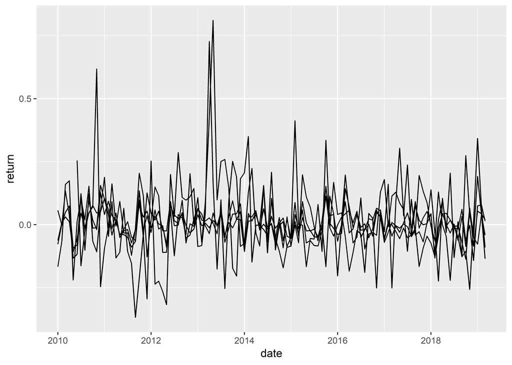

```r
# ggplot is from the ggplot2 package, a (the) premier library for static plots

# the ggplot function sets up the "rules" for the plot.
# The first argument is the data.frame to be used
# the next argument is aes(), which stands for aesthetics. This says which values should be passed
# on to other "geom_" functions, or layers of the plot for use
# here, date is the x variable, return is the y variable, and the data is plotted by group, using ticker

ggplot(data = all_monthly_stock_returns_stacked, aes(x = date, y = return, group = ticker)) +
  geom_line()
```

This plot shows one line for each stock ticker that represents monthly returns. I don’t see any weird discontinuities and the variability looks like what I would generally expect for stock returns.

One thing about this plot is it’s difficult to determine which line belonds to which stock. `ggplot2` makes it easy to plot groups of data, either by assinging different colors to values within a group, or by separating series into their own panels (or facets).

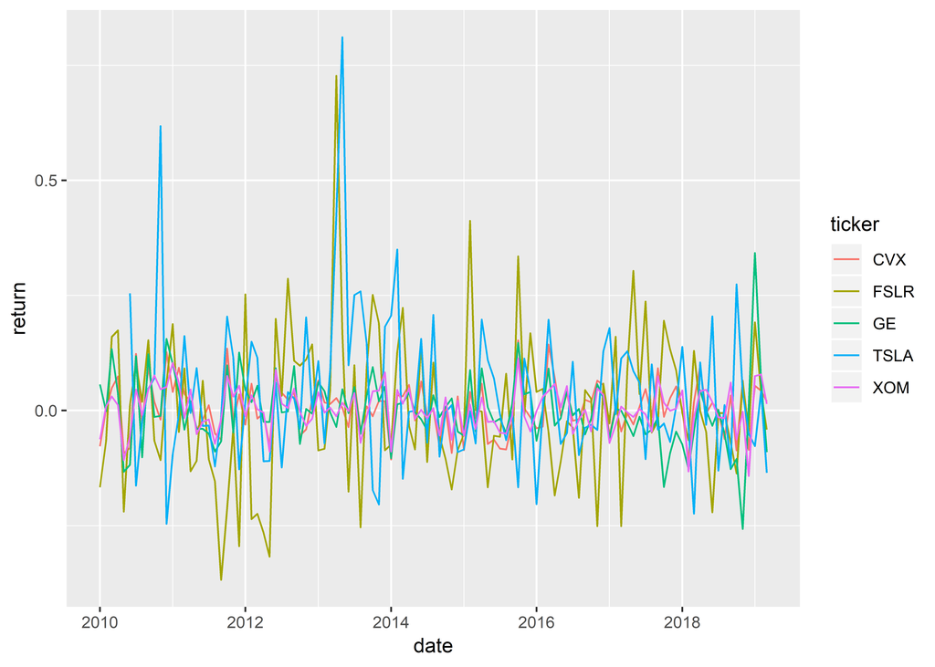

```r
# This version of the plot will group and color each line according to ticker
ggplot(all_monthly_stock_returns_stacked, aes(date, return, color = ticker)) +
  geom_line()
```

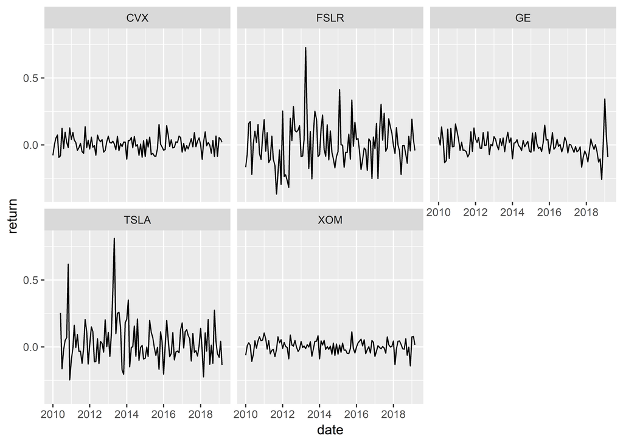

```r
# This version of the plot will split the lines into their own facets by ticker
ggplot(all_monthly_stock_returns_stacked, aes(date, return)) +
  facet_wrap(~ticker) +
  geom_line()
```

This data makes sense to me - larger, more established companies have much less variation in monthly returns than TSLA and FSLR. Data is available at regular intervals.

The next step is to get data for the S&P 500 and the risk free interest rate, which we will call the 13 week treasury bill rate. The same `get_monthly_returns` function can work for the S&P 500, and I’ll use getSymbols() directly for the treasury rate with the St. Louis Federal Reserve ( [FRED](https://fred.stlouisfed.org/) ) as a source. To download FRED data, I went to FRED and typed in “treasury bill rate” in the seach bar and was presented with a set of options for time series that match that description. The first series is what I want: “3-Month Treasury Bill: Secondary Market Rate.” Clicking the “monthly” option leads me to the following view:

[figure not shown]

```r
# download monthly returns for the S&P 500
sp500 = get_monthly_returns('^GSPC')

# get the monthly risk free rate from FRED
rf_rate = getSymbols('TB3MS', src = 'FRED', auto.assign = F)
rf_rate_adj = data.frame(
  return = rf_rate/100, # the risk free rate is presented as a percent, needs to be in same terms as the returns
  date = index(rf_rate)
  ) %>%
  rename(
    return = TB3MS
  )
tail(rf_rate_adj)
```

```
## # A tibble: 6 x 2
##   return date
##    <dbl> <date>
## 1 0.0213 2018-09-01
## 2 0.0225 2018-10-01
## 3 0.0233 2018-11-01
## 4 0.0237 2018-12-01
## 5 0.0237 2019-01-01
## 6 0.0239 2019-02-01
```

Now that I have all the data I need, I want to combine them for analysis. Since I want to run regressions of the form `(stock return - risk free rate) = alpha + beta(market_return - risk free rate) + error`, I need to have each stock return associated with the relevant risk free rate and market return for that month. We need to keep in mind that the stock returns are currently stacked on top of each other, so we can’t simply run a regression with all that data – we need to split the data by ticker and run each regression. There are efficient ways to do that in R, so it makes sense to keep those as a “long” `data.frame`.

```r
# I can do everything in one step:
# get rid of columns I don't want
# rename columns to something different
# use a left join to pull all the data together
joined_comparators = rf_rate_adj %>%
  rename(
    rf_rate_return = return # rename the return column to rf_rate_return
  ) %>%
  left_join(
    # Pay attention to what is happening here
    # I am doing the column dropping and renaming steps WITHIN the left_join call
    # This means the join will happen on the result of these operations
    select(sp500, -ticker) %>%
      rename(
        sp500_return = return
      )
  )
# Lets take a look at the result:
head(joined_comparators)
```

```
## # A tibble: 6 x 3
##   rf_rate_return date       sp500_return
##            <dbl> <date>            <dbl>
## 1        0.0072  1934-01-01           NA
## 2        0.0062  1934-02-01           NA
## 3        0.00240 1934-03-01           NA
## 4        0.0015  1934-04-01           NA
## 5        0.0016  1934-05-01           NA
## 6        0.0015  1934-06-01           NA
```

```r
tail(joined_comparators)
```

```
## # A tibble: 6 x 3
##   rf_rate_return date       sp500_return
##            <dbl> <date>            <dbl>
## 1         0.0213 2018-09-01      0.00429
## 2         0.0225 2018-10-01     -0.0694
## 3         0.0233 2018-11-01      0.0179
## 4         0.0237 2018-12-01     -0.0918
## 5         0.0237 2019-01-01      0.0787
## 6         0.0239 2019-02-01      0.0297
```

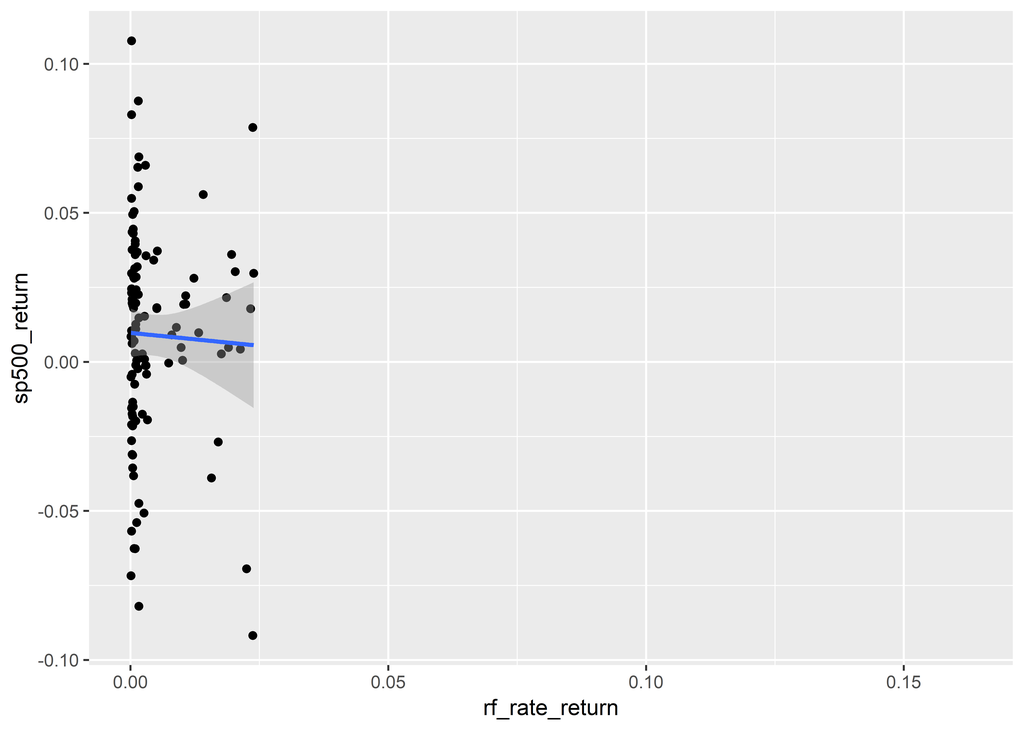

```r
# How do the series compare?
ggplot(joined_comparators, aes(rf_rate_return, sp500_return)) +
  geom_point() +
  stat_smooth(method = 'lm') # add a linear model to summarize the relationship
```

Now we have our comparators ready, we can join this data onto the stock tickers using the date column. We don’t have to worry about renaming any columns now – the only common column is `date`. I use a left join again because that is the safest join – it keeps all of the rows in the left hand side and only adds rows that match from the right. This allows one to see what data is potentially missing.